# Term Paper Mask

### FEDERAL STATE AUTONOMOUS EDUCATIONAL INSTITUTION FOR HIGHER EDUCATION

### NATIONAL RESEARCH UNIVERSITY HIGHER SCHOOL OF ECONOMICS

## MACHINE LEARNING (ARTIFICIAL INTELLIGENCE) AND MODERN CULTURE: EVENTS AND ARTIFACTS

Field of study 01.04.02 Applied Mathematics and Informatics  
Master’s programme “Data Analytics and Social Statistics”  
Faculty of Social Sciences

|  | **Scientific Supervisor** _____________________ **KARTASHEVA ANNA ALEXANDDROVNA** |
| --- | --- |

### Moscow 2026

# Overview

This notebook presents an empirical analysis of Reddit discussions about generative artificial intelligence in video game culture. It is conducted as part of Chapter 3 of the Term Paper titled "Machine learning (artificial intelligence) and modern culture: events and artifacts."

The notebook is built on two data sets gathered from Reddit through automated collection methods and stored in a PostgreSQL relational database. The first data set includes higher-level information, such as metadata from Reddit streams and manually encoded variables. The second data set consists of public reactions at the comment level related to Reddit posts.

- Author: Yuliya Mask
- Research topic: *Machine learning (artificial intelligence) and modern culture: events and artifacts*
- Empirical source: `Reddit`
- Database: PostgreSQL database `ai_in_games`
- The datasets used in this notebook: `post-level dataset.csv` , `comment-level dataset.csv`
- Software and libraries used: `Python, Jupyter Notebook, pandas, numpy, scipy, matplotlib, statsmodels, Static models`

# Introduction

Artificial intelligence is now embedded in all aspects of human life, automating routine tasks and complex computations. This marks the start of an era where AI shapes cultural norms, influences development trends, and provokes diverse reactions from society unprepared for such change.

The video game industry, characterized by its isolated community, offers a fitting context for examining issues related to two-dimensional perception and differing opinions on artificial intelligence. Games, whether completed or still in development, involve large companies or indie studios and blend visual art, storytelling, voice acting, music, and programming.

## The purpose of the work

The purpose of this term paper is to analyse perceptions of generative AI in video games in discussions on the Reddit platform within specialised communities, and to determine whether people's attitudes towards AI differ depending on their role in the industry.

## Research hypotheses

**Asymmetry by professional role (H1):** newcomers to the field will be more positive about generative AI than experienced developers.

**Asymmetry by type of AI use (H2):** the use of artificial intelligence in elements encountered by the player (illustrations, voice acting, and narration) elicits more negative reactions than when used as a tool for internal development.

## Methods

# Part I: Libraries and data uploading

This part imports the required Python libraries for the analysis and loads the two datasets exported from the database `ai_in_games`.

### Step 1.1: Setup

In this section, the necessary Python libraries are imported, display settings are configured, and project paths used in the analysis are defined.

```python
from pathlib import Path
import warnings
import numpy as np
import pandas as pd
import matplotlib.pyplot as plt
from scipy.stats import chi2_contingency, fisher_exact
from IPython.display import display, Markdown
warnings.filterwarnings("ignore")
```

### Step 1.2: Display settings for good-looking output

```python
pd.set_option("display.max_columns", 100)
pd.set_option("display.max_rows", 100)
pd.set_option("display.width", 160)
```

### Step 1.3: Load datasets

The imported datasets were successfully uploaded and consist of two tiers of Reddit data. The record-level dataset has **5355 records** and **13 variables**, with each row representing a Reddit post collected during the search. The comment-level dataset contains **32840 entries** and **14 variables**, where each row corresponds to a Reddit comment associated with the collected posts. The empirical analysis follows a two-tier structure: Reddit posts are examined to analyse discussion topics, author roles, types of artificial intelligence, information disclosure, and hypothesis matching. Meanwhile, Reddit comments are used to study community reactions and AI positioning.

```python
posts_dataset = pd.read_csv("post-level-dataset.csv")
comments_dataset = pd.read_csv("comment-level-dataset.csv")

print("Post-level-dataset shape:", posts_dataset.shape)
print("Comment-level-dataset shape:", comments_dataset.shape)
```

```
Post-level-dataset shape: (5355, 13)
Comment-level-dataset shape: (32840, 14)
```

### Step 1.4: Display first 5 rows of each dataset

All the data was uploaded successfully.

```python
display(posts_dataset.head())
display(comments_dataset.head())
```

|  | article_id | source_id | url | title_hint | post_date | language | author_role | ai_stance | ai_type | disclosure_type | hypothesis_type | query_cluster | relevant_flag |
| --- | --- | --- | --- | --- | --- | --- | --- | --- | --- | --- | --- | --- | --- |
| 0 | 22014 | 22 | https://www.reddit.com/r/GameDevelopment/comme... | Established Game Team Seeking Leaders | NaN | NaN | NaN | NaN | NaN | NaN | NaN | NaN | False |
| 1 | 20235 | 22 | https://www.reddit.com/r/Games/comments/1ifu77... | The Scouring - Orc Group - Classic Fantasy RTS... | NaN | NaN | NaN | NaN | NaN | NaN | NaN | NaN | False |
| 2 | 22587 | 22 | https://www.reddit.com/r/IndieDev/comments/1kp... | Heard your feedback, here is the result. | NaN | NaN | NaN | NaN | NaN | NaN | NaN | NaN | False |
| 3 | 22012 | 22 | https://www.reddit.com/r/GameDevelopment/comme... | Learn how to integrate RTX Neural Rendering in... | NaN | NaN | NaN | NaN | NaN | NaN | NaN | NaN | False |
| 4 | 22013 | 22 | https://www.reddit.com/r/GameDevelopment/comme... | The idea of the game is about space and more. | NaN | NaN | NaN | NaN | NaN | NaN | NaN | NaN | False |

|  | public_reaction_id | article_id | source_id | reaction_date | reaction_text | engagement_total | platform | ai_stance | is_relevant | query_cluster | post_ai_type | post_disclosure_type | post_author_role | post_hypothesis_type |
| --- | --- | --- | --- | --- | --- | --- | --- | --- | --- | --- | --- | --- | --- | --- |
| 0 | 16730 | 18898 | 22 | 2026-02-01 | &gt;“I’ll figure it out” or “It’s not going to... | 1 | reddit | neutral | True | NaN | art | NaN | player | H1+H2 |
| 1 | 16732 | 18898 | 22 | 2026-02-01 | Any AI is too much AI. | 0 | reddit | neutral | True | NaN | art | NaN | player | H1+H2 |
| 2 | 16733 | 18898 | 22 | 2026-02-01 | lol don't hear the oldies afraid of change, as... | 0 | reddit | neutral | True | NaN | art | NaN | player | H1+H2 |
| 3 | 16734 | 18898 | 22 | 2026-02-01 | The only AI I personally use it to assist with... | 0 | reddit | neutral | True | NaN | art | NaN | player | H1+H2 |
| 4 | 16747 | 18914 | 22 | 2026-02-10 | The problem with these word guessers is just a... | 7 | reddit | neutral | True | NaN | NaN | NaN | NaN | NaN |

# Part II: Data Inspection and Cleaning

In this part, the structure of both datasets is checked, duplicate identifiers are removed, categorical variables are standardized, and purified datasets are prepared for descriptive statistics and hypothesis testing.

### Step 2.1: Display column names

Here we can inspect the names of the columns we will work with.

```python
posts_columns = pd.DataFrame({
    "Column number": range(1, len(posts_dataset.columns) + 1),
    "Post-level variable": posts_dataset.columns
})
comments_columns = pd.DataFrame({
    "Column number": range(1, len(comments_dataset.columns) + 1),
    "Comment-level variable": comments_dataset.columns
})
display(Markdown("### Post-level dataset columns"))
display(posts_columns)

display(Markdown("### Comment-level dataset columns"))
display(comments_columns)
```

Post-level dataset columns

|  | Column number | Post-level variable |
| --- | --- | --- |
| 0 | 1 | article_id |
| 1 | 2 | source_id |
| 2 | 3 | url |
| 3 | 4 | title_hint |
| 4 | 5 | post_date |
| 5 | 6 | language |
| 6 | 7 | author_role |
| 7 | 8 | ai_stance |
| 8 | 9 | ai_type |
| 9 | 10 | disclosure_type |
| 10 | 11 | hypothesis_type |
| 11 | 12 | query_cluster |
| 12 | 13 | relevant_flag |

Comment-level dataset columns

|  | Column number | Comment-level variable |
| --- | --- | --- |
| 0 | 1 | public_reaction_id |
| 1 | 2 | article_id |
| 2 | 3 | source_id |
| 3 | 4 | reaction_date |
| 4 | 5 | reaction_text |
| 5 | 6 | engagement_total |
| 6 | 7 | platform |
| 7 | 8 | ai_stance |
| 8 | 9 | is_relevant |
| 9 | 10 | query_cluster |
| 10 | 11 | post_ai_type |
| 11 | 12 | post_disclosure_type |
| 12 | 13 | post_author_role |
| 13 | 14 | post_hypothesis_type |

### Step 2.2: Check duplicated primary identifiers before cleaning

The posts and comments were collected with a Python web-scraping script, so firstly, we need to explore whether the datasets contain duplicates As a result, we get various duplicates - 1 post and 20 comments — which we will remove.

```python
post_duplicate_ids = posts_dataset["article_id"].duplicated().sum()
comment_duplicate_ids = comments_dataset["public_reaction_id"].duplicated().sum()
print("Duplicated article_id values in posts:", post_duplicate_ids)
print("Duplicated public_reaction_id values in comments:", comment_duplicate_ids)
```

```
Duplicated article_id values in posts: 1
Duplicated public_reaction_id values in comments: 20
```

### Step 2.3: Remove duplicates by primary identifiers

We remove duplicates. After removing duplicates, the record-level dataset has **5,354 records**, while the comment-level dataset includes **32,820 records**. This indicates that one duplicate publication ID and 20 duplicate comment IDs were eliminated prior to further analysis.

```python
posts_clean = posts_dataset.drop_duplicates(subset=["article_id"]).copy()
comments_clean = comments_dataset.drop_duplicates(subset=["public_reaction_id"]).copy()
print("Post-level dataset after duplicate removal:", posts_clean.shape)
print("Comment-level dataset after duplicate removal:", comments_clean.shape)
```

```
Post-level dataset after duplicate removal: (5354, 13)
Comment-level dataset after duplicate removal: (32820, 14)
```

### Step 2.4: Standardise empty values

Missing values are present in datasets, and before carrying out work, they must be reduced to one understandable form.

```python
empty_values = ["", " ", "nan", "NaN", "None", "NULL", "null"]
posts_clean = posts_clean.replace(empty_values, np.nan)
comments_clean = comments_clean.replace(empty_values, np.nan)
```

### Step 2.5: Standardise categorical variables

To ensure all values have a single format (no spaces), which can especially occur during manual processing, we reduce the variables to a single type.

```python
post_categorical_columns = [
    "language",
    "author_role",
    "ai_stance",
    "ai_type",
    "disclosure_type",
    "hypothesis_type",
    "query_cluster"
]

comment_categorical_columns = [
    "platform",
    "ai_stance",
    "query_cluster",
    "post_ai_type",
    "post_disclosure_type",
    "post_author_role",
    "post_hypothesis_type"
]

for col in post_categorical_columns:
    if col in posts_clean.columns:
        posts_clean[col] = posts_clean[col].astype("string").str.strip().str.lower()

for col in comment_categorical_columns:
    if col in comments_clean.columns:
        comments_clean[col] = comments_clean[col].astype("string").str.strip().str.lower()
```

### Step 2.6: Check main categorical variables after standardisation

After manipulations with variables, we check for the result.

Checking the categorical variables shows that only a subset of the collected records received manual encoding at the column level. The missing values in `author_role`, `ai_stance`, `ai_type`, and `disclosure_type` mostly correspond to records collected during the search phase but not saved for analytical encoding. At the comment level, 16,044 comments were marked as relevant, while 16,776 comments were marked as irrelevant. Thus, the following analysis separates the complete collected data set from the final analytical subset used to test hypotheses.

```python
print("Post-level author_role:")
print(posts_clean["author_role"].value_counts(dropna=False))
print("\nPost-level ai_stance:")
print(posts_clean["ai_stance"].value_counts(dropna=False))
print("\nPost-level ai_type:")
print(posts_clean["ai_type"].value_counts(dropna=False))
print("\nPost-level disclosure_type:")
print(posts_clean["disclosure_type"].value_counts(dropna=False))
print("\nComment-level ai_stance:")
print(comments_clean["ai_stance"].value_counts(dropna=False))
print("\nComment-level is_relevant:")
print(comments_clean["is_relevant"].value_counts(dropna=False))
```

```
Post-level author_role:
author_role
<NA>         4752
developer     353
player        201
outsider       42
unclear         6
Name: count, dtype: Int64

Post-level ai_stance:
ai_stance
<NA>        4752
neutral      180
negative     161
question     153
positive     108
Name: count, dtype: Int64

Post-level ai_type:
ai_type
<NA>        4752
art          276
general      127
voice         82
tools         67
gameplay      50
Name: count, dtype: Int64

Post-level disclosure_type:
disclosure_type
<NA>          5219
voluntary       95
discovered      40
Name: count, dtype: Int64

Comment-level ai_stance:
ai_stance
<NA>        16776
neutral     13322
negative     2110
positive      612
Name: count, dtype: Int64

Comment-level is_relevant:
is_relevant
False    16776
True     16044
Name: count, dtype: int64
```

### Step 2.7: Create analytical subsets

At this stage, the data set is reduced to an analytical subset. Irrelevant publications are excluded because they do not contain a meaningful discussion of artificial intelligence in games. Only comments related to relevant publications and marked as relevant are saved at the comment level. This ensures that the next analysis will be based only on data directly relevant to the issue under study.

After cleaning, the record-level dataset contains **5354 records**, of which **592** are marked as important for analysis. The dataset at the comment level contains **32820 comments** after duplicates are removed. Among them, **8630 comments** are related to relevant publications, and **6666 comments** are both related to relevant publications and marked as relevant.

Thus, the final analytical sample consists of **592 relevant publications** and **6666 relevant comments**. These data are used in the following descriptive statistics and hypothesis testing.

```python
posts_relevant = posts_clean[posts_clean["relevant_flag"] == True].copy()
comments_from_relevant_posts = comments_clean[
    comments_clean["article_id"].isin(posts_relevant["article_id"])
].copy()
comments_relevant = comments_from_relevant_posts[
    comments_from_relevant_posts["is_relevant"] == True
].copy()
print("All cleaned posts:", posts_clean.shape)
print("Relevant posts:", posts_relevant.shape)
print("All cleaned comments:", comments_clean.shape)
print("Comments linked to relevant posts:", comments_from_relevant_posts.shape)
print("Relevant comments linked to relevant posts:", comments_relevant.shape)
```

```
All cleaned posts: (5354, 13)
Relevant posts: (592, 13)
All cleaned comments: (32820, 14)
Comments linked to relevant posts: (8630, 14)
Relevant comments linked to relevant posts: (6666, 14)
```

# Part III: Descriptive overview of the empirical dataset

This section examines the data. which were collected.

### Step 3.1: Data overview

The data flow table shows that after removing duplicates, the record-level dataset contains 5354 records, but only 592 are considered relevant for analysis. Most of the collected messages were excluded as irrelevant, while 233 messages lacked a relevance flag.

At the comment level, the cleaned dataset contains 32820 comments. After restricting the analysis to comments linked to relevant posts and excluding non-relevant comments, the final analytical comment-level dataset contains 6,666 comments. Therefore, the empirical analysis is based on 592 relevant posts and 6666 relevant comments.

```python
dataset_overview = pd.DataFrame({
    "Dataset component": [
        "All posts after duplicate removal",
        "Posts retained as relevant",
        "Posts excluded as non-relevant",
        "Posts with missing relevance flag",
        "All comments after duplicate removal",
        "Comments linked to relevant posts",
        "Relevant comments linked to relevant posts",
        "Irrelevant comments linked to relevant posts"
    ],
    "Number of records": [
        len(posts_clean),
        int(posts_clean["relevant_flag"].eq(True).sum()),
        int(posts_clean["relevant_flag"].eq(False).sum()),
        int(posts_clean["relevant_flag"].isna().sum()),
        len(comments_clean),
        len(comments_from_relevant_posts),
        int(comments_from_relevant_posts["is_relevant"].eq(True).sum()),
        int(comments_from_relevant_posts["is_relevant"].eq(False).sum())
    ]
})
display(dataset_overview.style.hide(axis="index"))
```

| Dataset component | Number of records |
| --- | --- |
| All posts after duplicate removal | 5354 |
| Posts retained as relevant | 592 |
| Posts excluded as non-relevant | 4529 |
| Posts with missing relevance flag | 233 |
| All comments after duplicate removal | 32820 |
| Comments linked to relevant posts | 8630 |
| Relevant comments linked to relevant posts | 6666 |
| Irrelevant comments linked to relevant posts | 1964 |

### Step 3.2: Descriptive statistics

Create function for frequency tables:

```python
def frequency_table(series, name):
    table = series.value_counts(dropna=False).rename_axis(name).reset_index(name="n")
    table["%"] = (table["n"] / table["n"].sum() * 100).round(2)
    return table
```

#### Explore the results of relevant posts and comments, ai_stance

At the comment level, AI's dominant position is neutral: 80.96% of the relevant comments are neutral, 14.94% are negative, and 4.10% are positive. At the post level, the distribution is more balanced: 29.90% of the relevant posts are neutral, 27.20% are negative, 25.17% are questions, and 17.74% are positive.

```python
post_relevance_table = frequency_table(posts_clean["relevant_flag"], "relevant_flag")
comment_relevance_table = frequency_table(
    comments_from_relevant_posts["is_relevant"],
    "is_relevant"
)
comment_stance_table = frequency_table(
    comments_relevant["ai_stance"],
    "comment_ai_stance"
)
post_original_stance_table = frequency_table(
    posts_relevant["ai_stance"],
    "post_ai_stance"
)
display(Markdown("### Relevance of the posts"))
display(post_relevance_table.style.hide(axis="index"))
display(Markdown("### Relevance of the comments among comments connected to relevant posts"))
display(comment_relevance_table.style.hide(axis="index"))
display(Markdown("### Comment-level ai_stance among relevant comments"))
display(comment_stance_table.style.hide(axis="index"))
display(Markdown("### Post-level ai_stance among relevant posts"))
display(post_original_stance_table.style.hide(axis="index"))
```

Relevance of the posts

| relevant_flag | n | % |
| --- | --- | --- |
| False | 4529 | 84.590000 |
| True | 592 | 11.060000 |
| nan | 233 | 4.350000 |

Relevance of the comments among comments connected to relevant posts

| is_relevant | n | % |
| --- | --- | --- |
| True | 6666 | 77.240000 |
| False | 1964 | 22.760000 |

Comment-level ai_stance among relevant comments

| comment_ai_stance | n | % |
| --- | --- | --- |
| neutral | 5397 | 80.960000 |
| negative | 996 | 14.940000 |
| positive | 273 | 4.100000 |

Post-level ai_stance among relevant posts

| post_ai_stance | n | % |
| --- | --- | --- |
| neutral | 177 | 29.900000 |
| negative | 161 | 27.200000 |
| question | 149 | 25.170000 |
| positive | 105 | 17.740000 |

#### Explore the structure of the relevant posts.

Here we have:

- `author_role` (who wrote the post: developer, player, outsider, unclear);
- `ai_type` (what type of AI is being discussed: art, voice, tools, gameplay, general);
- `disclosure_type` (how it became known about AI: voluntary, discovered, or missing);
- `hypothesis_type` (what hypothesis does the post refer to?).

Tables with post descriptions show that the majority of relevant posts were written by developers (58.61%).

Players account for (33.28%), while outsiders make up a smaller part of the dataset (7%).

The most common type of AI is artificial memory created with the help of AI, which accounts for (46.45%). General discussions of artificial intelligence include (21.45%), voice (12%), internal tools (11%), and gameplay (8%).

Disclosure information is only available for a small number of messages. Most of the messages do not have a specific type of disclosure, while 16.05% are coded as voluntary disclosure and 6.76% as detected use of artificial intelligence. A comparison of hypotheses shows that many publications are associated with several hypotheses, especially with the combined category H1+H2.

```python
post_author_role_table = frequency_table(
    posts_relevant["author_role"],
    "author_role"
)
post_ai_type_table = frequency_table(
    posts_relevant["ai_type"],
    "ai_type"
)
post_disclosure_type_table = frequency_table(
    posts_relevant["disclosure_type"],
    "disclosure_type"
)
post_hypothesis_type_table = frequency_table(
    posts_relevant["hypothesis_type"],
    "hypothesis_type"
)
display(Markdown("### Post-level author role distribution"))
display(post_author_role_table.style.hide(axis="index"))
display(Markdown("### Post-level AI type distribution"))
display(post_ai_type_table.style.hide(axis="index"))
display(Markdown("### Post-level disclosure type distribution"))
display(post_disclosure_type_table.style.hide(axis="index"))
display(Markdown("### Post-level hypothesis type distribution"))
display(post_hypothesis_type_table.style.hide(axis="index"))
```

Post-level author role distribution

| author_role | n | % |
| --- | --- | --- |
| developer | 347 | 58.610000 |
| player | 197 | 33.280000 |
| outsider | 42 | 7.090000 |
| unclear | 6 | 1.010000 |

Post-level AI type distribution

| ai_type | n | % |
| --- | --- | --- |
| art | 275 | 46.450000 |
| general | 127 | 21.450000 |
| voice | 74 | 12.500000 |
| tools | 67 | 11.320000 |
| gameplay | 49 | 8.280000 |

Post-level disclosure type distribution

| disclosure_type | n | % |
| --- | --- | --- |
|  | 457 | 77.200000 |
| voluntary | 95 | 16.050000 |
| discovered | 40 | 6.760000 |

Post-level hypothesis type distribution

| hypothesis_type | n | % |
| --- | --- | --- |
| h1+h2 | 161 | 27.200000 |
| h2 | 118 | 19.930000 |
| h3 | 102 | 17.230000 |
| h1 | 101 | 17.060000 |
| h2+h3 | 78 | 13.180000 |
| h1+h3 | 21 | 3.550000 |
| h1+h2+h3 | 11 | 1.860000 |

#### Explore what types of posts are relevant to comments

Descriptive tables at the comment level show that the most relevant comments concern publications on artificial intelligence. These comments account for 44.55% of the final analytical subgroup at the comment level. General AI discussions account for 22.61%, while voice AI and internal tools account for about 13% of relevant comments.

The most relevant comments are related to publications that do not specify the type of information disclosure. Voluntary disclosure accounts for 14.24% of relevant comments, while the detected use of artificial intelligence accounts for 7.01%.

The distribution by author roles is similar to the structure by publication level: the majority of relevant comments are related to publications written by developers (56.81%) and players (35.34%). Comments related to outsider posts make up a smaller part of the dataset.

```python
comment_post_ai_type_table = frequency_table(
    comments_relevant["post_ai_type"],
    "post_ai_type"
)
comment_post_disclosure_type_table = frequency_table(
    comments_relevant["post_disclosure_type"],
    "post_disclosure_type"
)
comment_post_author_role_table = frequency_table(
    comments_relevant["post_author_role"],
    "post_author_role"
)
display(Markdown("### Relevant comments by post AI type"))
display(comment_post_ai_type_table.style.hide(axis="index").format({"%": "{:.2f}"}))
display(Markdown("### Relevant comments by post disclosure type"))
display(comment_post_disclosure_type_table.style.hide(axis="index").format({"%": "{:.2f}"}))
display(Markdown("### Relevant comments by post author role"))
display(comment_post_author_role_table.style.hide(axis="index").format({"%": "{:.2f}"}))
```

Relevant comments by post AI type

| post_ai_type | n | % |
| --- | --- | --- |
| art | 2970 | 44.55 |
| general | 1507 | 22.61 |
| voice | 881 | 13.22 |
| tools | 880 | 13.20 |
| gameplay | 428 | 6.42 |

Relevant comments by post disclosure type

| post_disclosure_type | n | % |
| --- | --- | --- |
|  | 5250 | 78.76 |
| voluntary | 949 | 14.24 |
| discovered | 467 | 7.01 |

Relevant comments by post author role

| post_author_role | n | % |
| --- | --- | --- |
| developer | 3787 | 56.81 |
| player | 2356 | 35.34 |
| outsider | 485 | 7.28 |
| unclear | 38 | 0.57 |

#### Basic visualisations

Summary of the tables above on the graphs.

```python
def bar_chart_from_table(df, category_col, value_col, title, xlabel="", ylabel="Number of records"):
    plot_df = df.dropna(subset=[category_col]).copy()
    plot_df = plot_df.sort_values(value_col, ascending=False)

    plt.figure(figsize=(8, 5))
    bars = plt.bar(
        plot_df[category_col],
        plot_df[value_col],
        color="pink",
        edgecolor="black",
        linewidth=1.5
    )
    plt.title(title, color="black", fontsize=14)
    plt.xlabel(xlabel, color="black")
    plt.ylabel(ylabel, color="black")
    plt.xticks(rotation=45, ha="right", color="black")
    plt.yticks(color="black")
    for bar in bars:
        height = bar.get_height()
        plt.text(
            bar.get_x() + bar.get_width() / 2,
            height,
            f"{int(height)}",
            ha="center",
            va="bottom",
            color="black",
            fontsize=10
        )

    plt.tight_layout()
    plt.show()
```

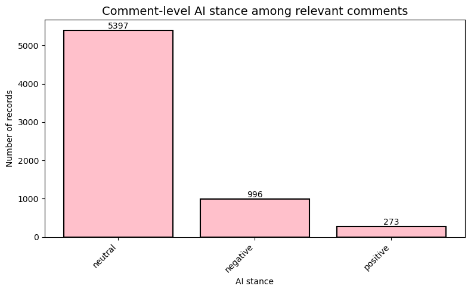

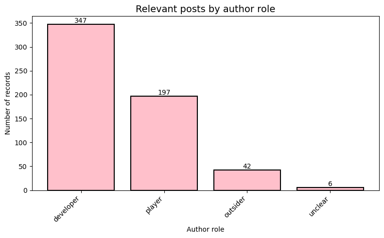

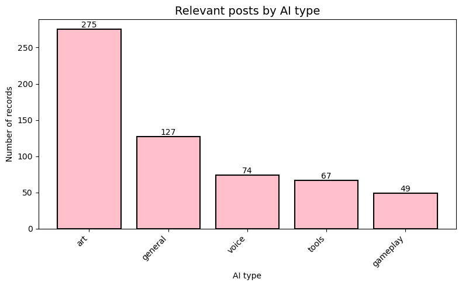

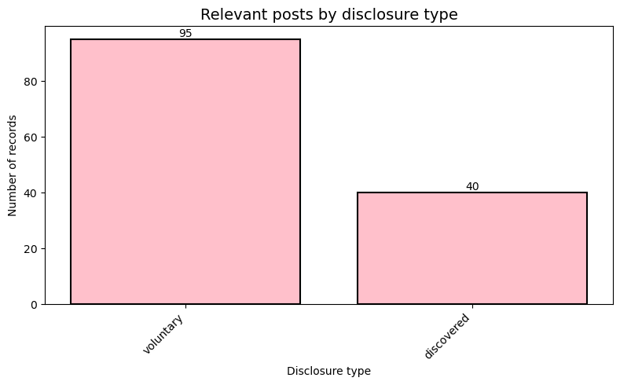

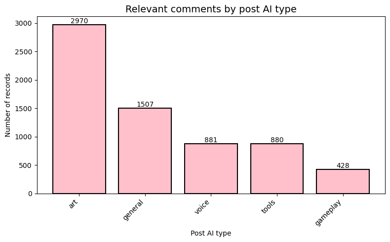

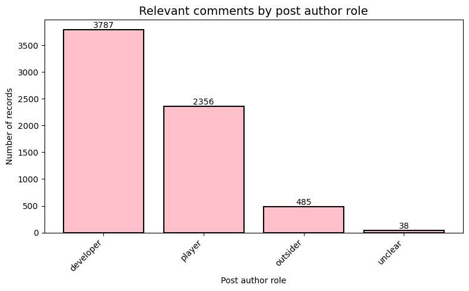

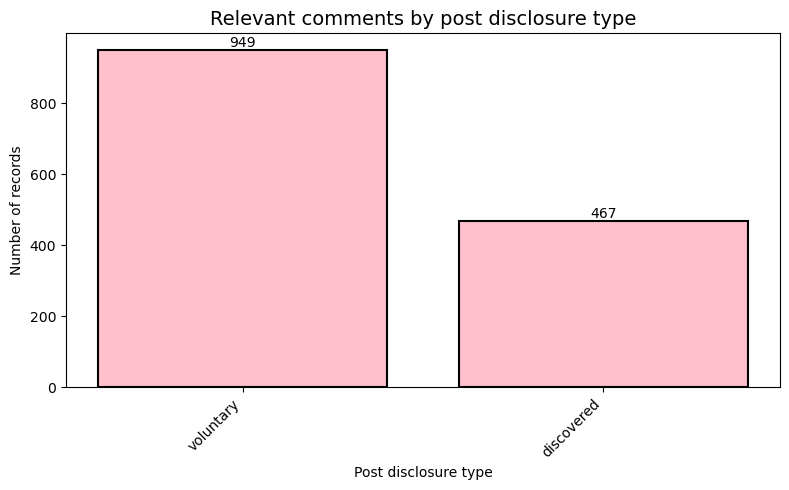

```python
bar_chart_from_table(
    comment_stance_table,
    "comment_ai_stance",
    "n",
    "Comment-level AI stance among relevant comments",
    xlabel="AI stance"
)

bar_chart_from_table(
    post_author_role_table,
    "author_role",
    "n",
    "Relevant posts by author role",
    xlabel="Author role"
)

bar_chart_from_table(
    post_ai_type_table,
    "ai_type",
    "n",
    "Relevant posts by AI type",
    xlabel="AI type"
)

bar_chart_from_table(
    post_disclosure_type_table,
    "disclosure_type",
    "n",
    "Relevant posts by disclosure type",
    xlabel="Disclosure type"
)

bar_chart_from_table(
    comment_post_ai_type_table,
    "post_ai_type",
    "n",
    "Relevant comments by post AI type",
    xlabel="Post AI type"
)

bar_chart_from_table(
    comment_post_author_role_table,
    "post_author_role",
    "n",
    "Relevant comments by post author role",
    xlabel="Post author role"
)

bar_chart_from_table(
    comment_post_disclosure_type_table,
    "post_disclosure_type",
    "n",
    "Relevant comments by post disclosure type",
    xlabel="Post disclosure type"
)
```

# Part IV: Auxiliary functions for hypothesis testing

This section describes reusable functions for cross-tabulation, row percentage calculation, the chi-square test, and Сramer's V. These functions will be used later to test H1, H2, and H3 in the same format.

```python
def crosstab_counts(df, row, col):
    """Сross-tabulation for two categorical variables"""
    data = df.dropna(subset=[row, col]).copy()
    return pd.crosstab(data[row], data[col])

def row_percent_table(table):
    """Сross-tabulation into %."""
    return (table.div(table.sum(axis=1), axis=0) * 100).round(2)

def cramers_v(table):
    """Cramér's V effect size for a contingency table"""
    chi2, p, dof, expected = chi2_contingency(table)
    n = table.to_numpy().sum()
    r, k = table.shape

    if min(r - 1, k - 1) == 0:
        return np.nan
    return np.sqrt((chi2 / n) / min(r - 1, k - 1))

def association_test(table, label):
    """Chi-square test with a compact summary"""
    chi2, p, dof, expected = chi2_contingency(table)
    min_expected = expected.min()
    v = cramers_v(table)

    test_summary = pd.DataFrame({
        "analysis": [label],
        "chi2": [round(chi2, 4)],
        "p_value": [round(p, 6)],
        "dof": [dof],
        "min_expected_count": [round(float(min_expected), 4)],
        "cramers_v": [round(float(v), 4)]
    })

    return test_summary
def run_categorical_analysis(df, row, col, label):
    """Display the results: counts, row percentages, and chi-square test"""
    counts = crosstab_counts(df, row, col)
    percentages = row_percent_table(counts)
    summary = association_test(counts, label)

    display(Markdown(f"### {label}"))
    display(Markdown("**Counts**"))
    display(counts)

    display(Markdown("**Row percentages**"))
    display(percentages)

    display(Markdown("**Test summary**"))
    display(summary)

    return counts, percentages, summary
```

# Part V: Asymmetry in professional roles (H1)

In H1, newcomers and outsiders are expected to be more positive about generative AI than experienced developers. Since the roles of commentators are usually indeterminate, H1 is tested mainly at the post level.

For this test, messages encoded as "questions" are recoded as "neutral" because the question does not imply direct approval or rejection.

### Step 5.1: Recode question as neutral

Now questions are interpreted as a neutral opinion.

```python
posts_relevant["post_stance_3"] = posts_relevant["ai_stance"].replace({
    "question": "neutral"
})
posts_relevant["post_stance_3"].value_counts()
```

```
post_stance_3
neutral     326
negative    161
positive    105
Name: count, dtype: Int64
```

### Step 5.2: Descriptive crosstab including all roles

A descriptive cross-table shows notable differences between author categories and roles.

- Outsiders have the highest proportion of positive reviews for ai_stance (40.48%), while developers have the lowest (12.68%).
- Developers are mostly neutral (65.71%), while players show the largest share of a negative position (39.59%).
- Unclear is presented in the form of a description, but is excluded from the main statistical test because it does not reflect the essential role of the author.

```python
h1_all_counts = crosstab_counts(
    posts_relevant,
    "author_role",
    "post_stance_3"
)

h1_all_percent = row_percent_table(h1_all_counts)
display(Markdown("### escriptive crosstab including all author_role categories (H1)"))
display(Markdown("**Counts**"))
display(h1_all_counts)
display(Markdown("**Row percentages**"))
display(h1_all_percent)
```

H1 descriptive crosstab including all author_role categories

**Counts**

| post_stance_3 author_role | negative | neutral | positive |
| --- | --- | --- | --- |
| developer | 75 | 228 | 44 |
| outsider | 6 | 19 | 17 |
| player | 78 | 75 | 44 |
| unclear | 2 | 4 | 0 |

**Row percentages**

| post_stance_3 author_role | negative | neutral | positive |
| --- | --- | --- | --- |
| developer | 21.61 | 65.71 | 12.68 |
| outsider | 14.29 | 45.24 | 40.48 |
| player | 39.59 | 38.07 | 22.34 |
| unclear | 33.33 | 66.67 | 0.00 |

### Step 5.3: H1 testing

The H1 test excludes an unclear category and compares developers, players, and outsiders. The results show a clear difference in the AI's position after completing the level, depending on the authors' roles. Outsiders show the highest positive attitude (40.48%), while developers show the lowest (12.68%). The players show the highest proportion of negative positions (39.59%).

The chi-square test indicates a statistically significant relationship between the author's role and the AI's position, x^2 (4) = 55.35, p < 0.001. The Kramer coefficient is 0.217, indicating a weak or moderate connection. Hence, H1 is supported: outside observers and less professionally involved participants are more positive about generative AI than developers.

```python
h1_posts = posts_relevant[
    posts_relevant["author_role"].isin(["developer", "player", "outsider"])
].copy()

h1_counts, h1_percent, h1_summary = run_categorical_analysis(
    h1_posts,
    row="author_role",
    col="post_stance_3",
    label="author_role and post-level AI stance (H1)"
)
```

Author role and post-level AI stance (H1)

**Counts**

| post_stance_3 author_role | negative | neutral | positive |
| --- | --- | --- | --- |
| developer | 75 | 228 | 44 |
| outsider | 6 | 19 | 17 |
| player | 78 | 75 | 44 |

**Row percentages**

| post_stance_3 author_role | negative | neutral | positive |
| --- | --- | --- | --- |
| developer | 21.61 | 65.71 | 12.68 |
| outsider | 14.29 | 45.24 | 40.48 |
| player | 39.59 | 38.07 | 22.34 |

**Test summary**

|  | analysis | chi2 | p_value | dof | min_expected_count | cramers_v |
| --- | --- | --- | --- | --- | --- | --- |
| 0 | Author role and post-level AI stance (H1) | 55.3513 | 0.0 | 4 | 7.5256 | 0.2173 |

### Step 5.4: Visualization of H1 testing

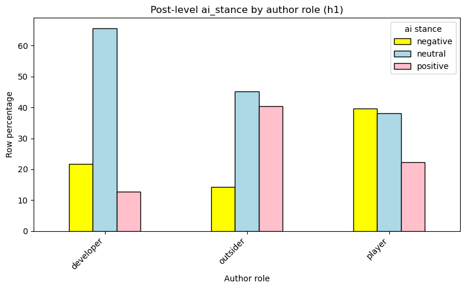

```python
ax = h1_percent.plot(
    kind="bar",
    figsize=(8, 5),
    color=["yellow", "lightblue", "pink"],
    edgecolor="black"
)
ax.set_title("Post-level ai_stance by author role (h1)", color="black")
ax.set_xlabel("Author role", color="black")
ax.set_ylabel("Row percentage", color="black")
plt.xticks(rotation=45, ha="right", color="black")
plt.yticks(color="black")
legend = plt.legend(title="ai stance")
plt.setp(legend.get_texts(), color="black")
plt.setp(legend.get_title(), color="black")
plt.tight_layout()
plt.show()
```

# Part VI: Asymmetry depending on the type of use of artificial intelligence (H2)

H2 predicts that visible AI applications like AI art, voice, gameplay features, character design, narrative content, or promotional materials will provoke more negative reactions than internal AI tools used for coding, prototyping, testing, localisation, or workflow efficiency.

This hypothesis is examined both through publications and comments.

### Step 6.1: Creation of subgroups for testing the H2 hypothesis

We can categorise AI types into three groups: art, voice, and gameplay. These can be combined into a new variable called visible_ai, while other tools are grouped as internal_tools, and general topics fall under general_discussion.

Grouping by H2 shows that the most relevant posts and comments are about applications with visible AI. Highlighting visible AI's prominence helps the audience see its importance, making them feel their focus on this area is recognised. At the publication level, visible AI accounts for 67.23% of referrals, while internal tools account for 11.32%. Visible AI also dominates at the comment level, accounting for 64.19% of relevant comments, compared with 13.20% for internal tools. This confirms that the dataset is suitable for comparing visible AI applications with internal AI tools.

```python
visible_ai_types = {"art", "voice", "gameplay"}
internal_ai_types = {"tools"}

def ai_visibility_group(x):
    if pd.isna(x):
        return pd.NA
    if x in visible_ai_types:
        return "visible_ai"
    if x in internal_ai_types:
        return "internal_tools"
    if x == "general":
        return "general_discussion"
    return pd.NA
posts_relevant["ai_visibility_group"] = posts_relevant["ai_type"].map(ai_visibility_group)
comments_relevant["post_ai_visibility_group"] = comments_relevant["post_ai_type"].map(ai_visibility_group)
display(Markdown("### Post-level ai_visibility_groups"))
display(
    frequency_table(
        posts_relevant["ai_visibility_group"],
        "ai_visibility_group"
    ).style.hide(axis="index").format({"%": "{:.2f}"})
)
display(Markdown("### Comment-level ai_visibility_groups"))
display(
    frequency_table(
        comments_relevant["post_ai_visibility_group"],
        "post_ai_visibility_group"
    ).style.hide(axis="index").format({"%": "{:.2f}"})
)
```

Post-level ai_visibility_groups

| ai_visibility_group | n | % |
| --- | --- | --- |
| visible_ai | 398 | 67.23 |
| general_discussion | 127 | 21.45 |
| internal_tools | 67 | 11.32 |

Comment-level ai_visibility_groups

| post_ai_visibility_group | n | % |
| --- | --- | --- |
| visible_ai | 4279 | 64.19 |
| general_discussion | 1507 | 22.61 |
| internal_tools | 880 | 13.20 |

### Step 6.2: Detailed post-level ai type comparison

Here, we can analyse whether the post-level AI stance differs across specific AI types.

Highlighting variation in AI perceptions across types, the data show that art using artificial intelligence has the highest share of negative evaluations (34.91%) and the lowest share of positive evaluations (9.45%), underscoring the controversy surrounding its use in the visual and artistic fields. Internal instruments are rated less negatively: 11.94% are negatively rated, and 23.88% are positively rated.

The chi-square test reveals a statistically significant relationship between AI type and evaluation levels after the course, x^2 (8) = 83.86, p < 0.001, emphasizing the importance of these findings. The Cramér coefficient of 0.266 suggests a weak to moderate association. These results support H2 at the post level, though the positive trend for gameplay-related AI should be interpreted cautiously due to fewer posts in this category.

```python
h2_post_counts, h2_post_percent, h2_post_summary = run_categorical_analysis(
    posts_relevant,
    row="ai_type",
    col="post_stance_3",
    label="Post ai type and post-level ai stance (H2 detailed)"
)
```

Post ai type and post-level AI stance (H2 detailed)

**Counts**

| post_stance_3 ai_type | negative | neutral | positive |
| --- | --- | --- | --- |
| art | 96 | 153 | 26 |
| gameplay | 2 | 19 | 28 |
| general | 38 | 72 | 17 |
| tools | 8 | 43 | 16 |
| voice | 17 | 39 | 18 |

**Row percentages**

| post_stance_3 ai_type | negative | neutral | positive |
| --- | --- | --- | --- |
| art | 34.91 | 55.64 | 9.45 |
| gameplay | 4.08 | 38.78 | 57.14 |
| general | 29.92 | 56.69 | 13.39 |
| tools | 11.94 | 64.18 | 23.88 |
| voice | 22.97 | 52.70 | 24.32 |

**Test summary**

|  | analysis | chi2 | p_value | dof | min_expected_count | cramers_v |
| --- | --- | --- | --- | --- | --- | --- |
| 0 | Post ai type and post-level AI stance (H2 deta... | 83.8592 | 0.0 | 8 | 8.6909 | 0.2661 |

### Step 6.3: Detailed comment-level ai type comparison

Here we will look at whether the location of the comments depends on which type of artificial intelligence the post belonged to.

A comparison at the H2 comment level shows that the position of AI also differs across post types, with AI, though the differences are smaller than at the post level. Comments related to artificial intelligence publications have the highest negative rating (16.87%), while comments related to internal tools have a lower negative rating (10.57%). This picture corresponds to the H2 indicator, emphasising the nuanced nature of these relationships for data analysts and researchers.

The chi-square test indicates a statistically significant relationship between the type of AI in the post and the position of AI at the comment level, x^2 (8) = 42.24, p < 0.001. This demonstrates the importance of our analysis for the field, which should instil confidence in our findings among researchers and data analysts.

```python
h2_comment_counts, h2_comment_percent, h2_comment_summary = run_categorical_analysis(
    comments_relevant,
    row="post_ai_type",
    col="ai_stance",
    label="Post ai type and comment-level ai stance (H2 detailed)"
)
```

Post ai type and comment-level ai stance (H2 detailed)

**Counts**

| ai_stance post_ai_type | negative | neutral | positive |
| --- | --- | --- | --- |
| art | 501 | 2362 | 107 |
| gameplay | 39 | 375 | 14 |
| general | 240 | 1199 | 68 |
| tools | 93 | 738 | 49 |
| voice | 123 | 723 | 35 |

**Row percentages**

| ai_stance post_ai_type | negative | neutral | positive |
| --- | --- | --- | --- |
| art | 16.87 | 79.53 | 3.60 |
| gameplay | 9.11 | 87.62 | 3.27 |
| general | 15.93 | 79.56 | 4.51 |
| tools | 10.57 | 83.86 | 5.57 |
| voice | 13.96 | 82.07 | 3.97 |

**Test summary**

|  | analysis | chi2 | p_value | dof | min_expected_count | cramers_v |
| --- | --- | --- | --- | --- | --- | --- |
| 0 | Post ai type and comment-level ai stance (H2 d... | 42.2351 | 0.000001 | 8 | 17.5284 | 0.0563 |

### Step 6.4: Visible ai vs internal tools at the post level

Here we can check whether the post-level ai_stance differs between visible AI applications and internal AI tools.

A post-level binary comparison indicates that applications with visible AI tend to receive a greater share of negative feedback compared to internal AI tools. Specifically, 28.89% of reports mentioning visible AI are negative, whereas only 11.94% of reports for internal tools are negative. Additionally, internal tools show a marginally higher percentage of positive feedback.

The chi-square test reveals a statistically significant association between the AI's visibility group and its higher-level position, with x^2(2)= 8.56 and p = 0.014. Cramer's V is 0.136, suggesting a weak correlation. Overall, this supports H2 at the publication level.

```python
h2_post_binary = posts_relevant[
    posts_relevant["ai_visibility_group"].isin(["visible_ai", "internal_tools"])
].copy()

h2_binary_post_counts, h2_binary_post_percent, h2_binary_post_summary = run_categorical_analysis(
    h2_post_binary,
    row="ai_visibility_group",
    col="post_stance_3",
    label="Visible ai vs internal tools, post-level stance (H2 detailed)"
)
```

Visible ai vs internal tools, post-level stance (H2 detailed)

**Counts**

| post_stance_3 ai_visibility_group | negative | neutral | positive |
| --- | --- | --- | --- |
| internal_tools | 8 | 43 | 16 |
| visible_ai | 115 | 211 | 72 |

**Row percentages**

| post_stance_3 ai_visibility_group | negative | neutral | positive |
| --- | --- | --- | --- |
| internal_tools | 11.94 | 64.18 | 23.88 |
| visible_ai | 28.89 | 53.02 | 18.09 |

**Test summary**

|  | analysis | chi2 | p_value | dof | min_expected_count | cramers_v |
| --- | --- | --- | --- | --- | --- | --- |
| 0 | Visible ai vs internal tools, post-level stanc... | 8.5561 | 0.01387 | 2 | 12.6796 | 0.1356 |

### Step 6.5: Visible ai vs internal tools at the comment level

Here, we check whether comments under visible AI posts display a more negative stance than those under internal tools posts.

A binary comparison at the comment level reveals similar results as a test at the post level. Comments associated with notes that use artificial intelligence exhibit a higher percentage of negative sentiments (15.49%) compared to those related to internal tools (10.57%). Conversely, messages about internal tools tend to have a slightly more positive tone.

The chi-square test shows a statistically significant link between the AI visibility group and AI position at the comment level, x^2(2) = 19.68, p<0.001. Nevertheless, Cramer's V is 0.062, indicating a very weak association. Therefore, H2 remains valid at the comment level, but the effect size is small.

```python
h2_comment_binary = comments_relevant[
    comments_relevant["post_ai_visibility_group"].isin(["visible_ai", "internal_tools"])
].copy()

h2_binary_comment_counts, h2_binary_comment_percent, h2_binary_comment_summary = run_categorical_analysis(
    h2_comment_binary,
    row="post_ai_visibility_group",
    col="ai_stance",
    label="Visible ai vs internal tools, comment-level stance (H2 detailed)"
)
```

Visible ai vs internal tools, comment-level stance (H2 detailed)

**Counts**

| ai_stance post_ai_visibility_group | negative | neutral | positive |
| --- | --- | --- | --- |
| internal_tools | 93 | 738 | 49 |
| visible_ai | 663 | 3460 | 156 |

**Row percentages**

| ai_stance post_ai_visibility_group | negative | neutral | positive |
| --- | --- | --- | --- |
| internal_tools | 10.57 | 83.86 | 5.57 |
| visible_ai | 15.49 | 80.86 | 3.65 |

**Test summary**

|  | analysis | chi2 | p_value | dof | min_expected_count | cramers_v |
| --- | --- | --- | --- | --- | --- | --- |
| 0 | Visible ai vs internal tools, comment-level st... | 19.6847 | 0.000053 | 2 | 34.968 | 0.0618 |

### Step 6.6: Visualisation

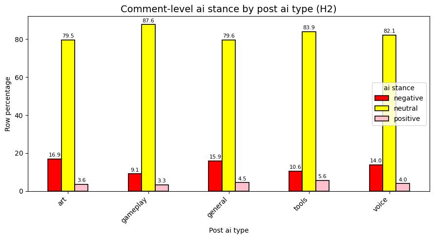

```python
ax = h2_comment_percent.plot(
    kind="bar",
    figsize=(9, 5),
    color=["red", "yellow", "pink"],
    edgecolor="black",
    linewidth=1.2
)

ax.set_title("Comment-level ai stance by post ai type (H2)", color="black", fontsize=14)
ax.set_xlabel("Post ai type", color="black")
ax.set_ylabel("Row percentage", color="black")

plt.xticks(rotation=45, ha="right", color="black")
plt.yticks(color="black")

legend = plt.legend(title="ai stance")
plt.setp(legend.get_texts(), color="black")
plt.setp(legend.get_title(), color="black")

for container in ax.containers:
    ax.bar_label(
        container,
        fmt="%.1f",
        label_type="edge",
        fontsize=8,
        color="black",
        padding=2
    )

plt.tight_layout()
plt.show()
```

# Part VII: Asymmetry by AI disclosure (H3)

H3 suggests that covert, discovered, or retroactive AI use may provoke more negative reactions than voluntary or open disclosures of information. In the current dataset, the primary categories of disclosure are voluntary and discovered, whereas missing data points to instances where disclosure was not a focus or could not be identified.

### Step 7.1: Post-level disclosure comparison

The H3 test reveals a significant difference between voluntary AI information disclosure and disclosed AI use. Reports of AI use are predominantly negative: 77.50% express negativity, with no positive reports. In contrast, voluntary disclosures are mostly neutral (77.89%) and include a notable proportion of positive attitudes (14.74%).

The chi-square test reveals a statistically significant link between the type of information disclosure and the AI's higher-level position, with x^2(2) = 69.13, p < 0.001. The Cramér's V coefficient is 0.716, indicating a strong association. Although the expected cell counts are just below 5, the overall descriptive pattern remains very clear. H3 is strongly supported at the post level.

```python
h3_posts = posts_relevant.dropna(subset=["disclosure_type"]).copy()

h3_post_counts, h3_post_percent, h3_post_summary = run_categorical_analysis(
    h3_posts,
    row="disclosure_type",
    col="post_stance_3",
    label="Disclosure type and post-level ai stance (H3)"
)
```

Disclosure type and post-level ai stance (H3)

**Counts**

| post_stance_3 disclosure_type | negative | neutral | positive |
| --- | --- | --- | --- |
| discovered | 31 | 9 | 0 |
| voluntary | 7 | 74 | 14 |

**Row percentages**

| post_stance_3 disclosure_type | negative | neutral | positive |
| --- | --- | --- | --- |
| discovered | 77.50 | 22.50 | 0.00 |
| voluntary | 7.37 | 77.89 | 14.74 |

**Test summary**

|  | analysis | chi2 | p_value | dof | min_expected_count | cramers_v |
| --- | --- | --- | --- | --- | --- | --- |
| 0 | Disclosure type and post-level ai stance (H3) | 69.128 | 0.0 | 2 | 4.1481 | 0.7156 |

### Step 7.2: Comment-level disclosure comparison

The pattern observed at the comment level for H3 differs from the post-level results. Comments linked to detected AI use are predominantly neutral (83.73%) with 14.35% showing a negative stance. Conversely, comments related to voluntary disclosure have a slightly higher proportion of negative reactions (18.55%). The chi-square test reveals a statistically significant relationship between the type of post disclosure and the AI stance in comments, with x^2(2) = 8.83 and p = 0.012. Nonetheless, Cramér’s V is only 0.079, suggesting a weak association. Since the observed comment pattern does not support the hypothesis that AI use detection elicits more negative responses, H3 is not confirmed at the comment level.

```python
h3_comments = comments_relevant.dropna(subset=["post_disclosure_type"]).copy()

h3_comment_counts, h3_comment_percent, h3_comment_summary = run_categorical_analysis(
    h3_comments,
    row="post_disclosure_type",
    col="ai_stance",
    label="Post disclosure type and comment-level ai stance (H3)"
)
```

Post disclosure type and comment-level ai stance (H3)

**Counts**

| ai_stance post_disclosure_type | negative | neutral | positive |
| --- | --- | --- | --- |
| discovered | 67 | 391 | 9 |
| voluntary | 176 | 735 | 38 |

**Row percentages**

| ai_stance post_disclosure_type | negative | neutral | positive |
| --- | --- | --- | --- |
| discovered | 14.35 | 83.73 | 1.93 |
| voluntary | 18.55 | 77.45 | 4.00 |

**Test summary**

|  | analysis | chi2 | p_value | dof | min_expected_count | cramers_v |
| --- | --- | --- | --- | --- | --- | --- |
| 0 | Post disclosure type and comment-level ai stan... | 8.8337 | 0.012072 | 2 | 15.5007 | 0.079 |

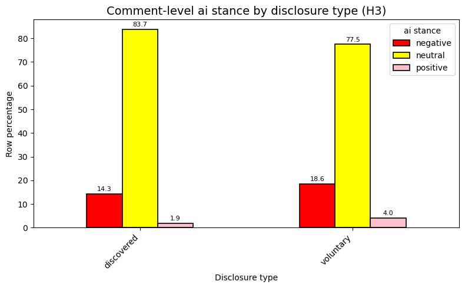

```python
ax = h3_comment_percent.plot(
    kind="bar",
    figsize=(8, 5),
    color=["red", "yellow", "pink"],
    edgecolor="black",
    linewidth=1.2
)

ax.set_title("Comment-level ai stance by disclosure type (H3)", color="black", fontsize=14)
ax.set_xlabel("Disclosure type", color="black")
ax.set_ylabel("Row percentage", color="black")

plt.xticks(rotation=45, ha="right", color="black")
plt.yticks(color="black")

legend = plt.legend(title="ai stance")
plt.setp(legend.get_texts(), color="black")
plt.setp(legend.get_title(), color="black")

for container in ax.containers:
    ax.bar_label(
        container,
        fmt="%.1f",
        label_type="edge",
        fontsize=8,
        color="black",
        padding=2
    )

plt.tight_layout()
plt.show()
```

# Part VIII: Additional Reliability Check: Binary negative rating models

The primary analysis relies on cross-tabulations and associative tests. For added reliability, the AI position is also transformed into a binary outcome: negative = 1 and positive/neutral = 0. These models are optional and should be viewed as supplementary evidence rather than the main approach of the coursework.

### Step 8.1: Import statsmodels and create binary variables

The findings indicate that 27.20% of relevant publications express a negative stance, compared to 14.94% of relevant comments. This suggests that negative reactions are more frequently observed at the publication level than in comments. The binary variables generated at this point are subsequently utilized in the logistic regression models.

```python
try:
    import statsmodels.formula.api as smf
    from patsy.contrasts import Treatment
    statsmodels_available = True
except Exception as e:
    statsmodels_available = False
    print("statsmodels is not available:", e)
posts_logit = posts_relevant.copy()
comments_logit = comments_relevant.copy()
posts_logit["negative_post_stance"] = (posts_logit["post_stance_3"] == "negative").astype(int)
comments_logit["negative_comment_stance"] = (comments_logit["ai_stance"] == "negative").astype(int)
print("Negative post-level stance:", round(posts_logit["negative_post_stance"].mean() * 100, 2), "%")
print("Negative comment-level stance:", round(comments_logit["negative_comment_stance"].mean() * 100, 2), "%")
```

```
Negative post-level stance: 27.2 %
Negative comment-level stance: 14.94 %
```

### Step 8.2: Helper function for logistic regression

```python
def run_logit_model(data, formula, label):
    if not statsmodels_available:
        print("statsmodels is not available and logistic regression cannot be estimated.")
        return None, None

    model = smf.logit(formula=formula, data=data).fit(disp=False)

    display(Markdown(f"### {label}"))
    print(model.summary())

    result_table = pd.DataFrame({
        "term": model.params.index,
        "coef": model.params.values,
        "odds_ratio": np.exp(model.params.values),
        "p_value": model.pvalues.values
    })

    result_table["coef"] = result_table["coef"].round(4)
    result_table["odds_ratio"] = result_table["odds_ratio"].round(4)
    result_table["p_value"] = result_table["p_value"].round(6)

    display(Markdown("**Compact interpretation table**"))
    display(result_table)

    return model, result_table
```

### Step 8.3 H2 robustness models

H2 robustness model at the post level:

The reliability model that follows supports H2. When the AI position is classified as a binary outcome, publications about visible AI applications tend to be more negative than those concerning internal tools. The probability coefficient for visible_ai is 2.997, indicating that the chance of a negative evaluation after passing the level is nearly three times greater for visible AI than for internal tools. This effect is statistically significant, with p = 0.005.

```python
h2_logit_posts = posts_logit[
    posts_logit["ai_visibility_group"].isin(["visible_ai", "internal_tools"])
].copy()

h2_post_model, h2_post_logit_table = run_logit_model(
    h2_logit_posts,
    formula='negative_post_stance ~ C(ai_visibility_group, Treatment(reference="internal_tools"))',
    label="Robustness: visible AI and negative post-level stance (H2)"
)
```

Robustness: visible AI and negative post-level stance (H2)

```
                            Logit Regression Results
================================================================================
Dep. Variable:     negative_post_stance   No. Observations:                  465
Model:                            Logit   Df Residuals:                      463
Method:                             MLE   Df Model:                            1
Date:                  Sat, 27 Jun 2026   Pseudo R-squ.:                 0.01809
Time:                          22:09:54   Log-Likelihood:                -263.78
converged:                         True   LL-Null:                       -268.64
Covariance Type:              nonrobust   LLR p-value:                  0.001823
===============================================================================================================================================
                                                                                  coef    std err          z      P>|z|      [0.025      0.975]
-----------------------------------------------------------------------------------------------------------------------------------------------
Intercept                                                                      -1.9981      0.377     -5.303      0.000      -2.737      -1.260
C(ai_visibility_group, Treatment(reference="internal_tools"))[T.visible_ai]     1.0976      0.393      2.795      0.005       0.328       1.867
===============================================================================================================================================
```

**Compact interpretation table**

|  | term | coef | odds_ratio | p_value |
| --- | --- | --- | --- | --- |
| 0 | Intercept | -1.9981 | 0.1356 | 0.000000 |
| 1 | C(ai_visibility_group, Treatment(reference="in... | 1.0976 | 2.9969 | 0.005186 |

H2 robustness model at the comments level:

The comment-level reliability model also underpins the H2 function. Comments on posts generated by artificial intelligence are more likely to receive negative evaluations than those on internal tools. The probability coefficient for visible AI is 1.552, indicating that the chance of a negative reaction at the comment level is roughly 1.55 times higher for visible AI than for internal tools. This finding is statistically significant (p < 0.001).

```python
h2_logit_comments = comments_logit[
    comments_logit["post_ai_visibility_group"].isin(["visible_ai", "internal_tools"])
].copy()

h2_comment_model, h2_comment_logit_table = run_logit_model(
    h2_logit_comments,
    formula='negative_comment_stance ~ C(post_ai_visibility_group, Treatment(reference="internal_tools"))',
    label="Robustness: visible AI and negative comment-level stance (H2)"
)
```

Robustness: visible AI and negative comment-level stance (H2)

```
                              Logit Regression Results
===================================================================================
Dep. Variable:     negative_comment_stance   No. Observations:                 5159
Model:                               Logit   Df Residuals:                     5157
Method:                                MLE   Df Model:                            1
Date:                     Sat, 27 Jun 2026   Pseudo R-squ.:                0.003532
Time:                             22:09:59   Log-Likelihood:                -2142.0
converged:                            True   LL-Null:                       -2149.5
Covariance Type:                 nonrobust   LLR p-value:                 9.740e-05
====================================================================================================================================================
                                                                                       coef    std err          z      P>|z|      [0.025      0.975]
----------------------------------------------------------------------------------------------------------------------------------------------------
Intercept                                                                           -2.1356      0.110    -19.477      0.000      -2.351      -1.921
C(post_ai_visibility_group, Treatment(reference="internal_tools"))[T.visible_ai]     0.4393      0.118      3.738      0.000       0.209       0.670
====================================================================================================================================================
```

**Compact interpretation table**

|  | term | coef | odds_ratio | p_value |
| --- | --- | --- | --- | --- |
| 0 | Intercept | -2.1356 | 0.1182 | 0.000000 |
| 1 | C(post_ai_visibility_group, Treatment(referenc... | 0.4393 | 1.5516 | 0.000185 |

### Step 8.4: H3 robustness models

H3 robustness model at the post level:

The post-H3 reliability model fully endorses H3. When information disclosure is represented as a binary predictor, AI detection is associated with a significantly higher likelihood of receiving a negative assessment than voluntary disclosure. The odds ratio for a discovered disclosure is 43.30, with a statistically significant p-value of less than 0.001. This reinforces the primary conclusion from the H3 level study: the detected or retroactive use of AI is far more likely to provoke a negative response than voluntary disclosure.

```python
h3_logit_posts = posts_logit[
    posts_logit["disclosure_type"].isin(["voluntary", "discovered"])
].copy()

h3_logit_posts["discovered_disclosure"] = (
    h3_logit_posts["disclosure_type"] == "discovered"
).astype(int)

h3_post_model, h3_post_logit_table = run_logit_model(
    h3_logit_posts,
    formula="negative_post_stance ~ discovered_disclosure",
    label="Robustness: discovered disclosure and negative post-level stance (H3)"
)
```

Robustness: discovered disclosure and negative post-level stance (H3)

```
                            Logit Regression Results
================================================================================
Dep. Variable:     negative_post_stance   No. Observations:                  135
Model:                            Logit   Df Residuals:                      133
Method:                             MLE   Df Model:                            1
Date:                  Sat, 27 Jun 2026   Pseudo R-squ.:                  0.4227
Time:                          22:10:00   Log-Likelihood:                -46.318
converged:                         True   LL-Null:                       -80.237
Covariance Type:              nonrobust   LLR p-value:                 1.775e-16
=========================================================================================
                            coef    std err          z      P>|z|      [0.025      0.975]
-----------------------------------------------------------------------------------------
Intercept                -2.5314      0.393     -6.446      0.000      -3.301      -1.762
discovered_disclosure     3.7682      0.546      6.908      0.000       2.699       4.837
=========================================================================================
```

**Compact interpretation table**

|  | term | coef | odds_ratio | p_value |
| --- | --- | --- | --- | --- |
| 0 | Intercept | -2.5314 | 0.0795 | 0.0 |
| 1 | discovered_disclosure | 3.7682 | 43.3016 | 0.0 |

H3 robustness model at the comments level:

The H3 reliability model at the comment level does not support H3. The probability coefficient for "discovered disclosure" is 0.736, indicating that comments about detected AI use are less likely to provoke a negative reaction compared to voluntary disclosures. This finding is statistically significant at the 5% level, with p = 0.049. This supports the earlier cross-table result: H3 is confirmed at the publication level but not at the comment level.

```python
h3_logit_comments = comments_logit[
    comments_logit["post_disclosure_type"].isin(["voluntary", "discovered"])
].copy()

h3_logit_comments["discovered_disclosure"] = (
    h3_logit_comments["post_disclosure_type"] == "discovered"
).astype(int)

h3_comment_model, h3_comment_logit_table = run_logit_model(
    h3_logit_comments,
    formula="negative_comment_stance ~ discovered_disclosure",
    label="Robustness: discovered disclosure and negative comment-level stance (H3)"
)
```

Robustness: discovered disclosure and negative comment-level stance (H3)

```
                              Logit Regression Results
===================================================================================
Dep. Variable:     negative_comment_stance   No. Observations:                 1416
Model:                               Logit   Df Residuals:                     1414
Method:                                MLE   Df Model:                            1
Date:                     Sat, 27 Jun 2026   Pseudo R-squ.:                0.003065
Time:                             22:10:01   Log-Likelihood:                -647.15
converged:                            True   LL-Null:                       -649.14
Covariance Type:                 nonrobust   LLR p-value:                   0.04607
=========================================================================================
                            coef    std err          z      P>|z|      [0.025      0.975]
-----------------------------------------------------------------------------------------
Intercept                -1.4798      0.084    -17.718      0.000      -1.643      -1.316
discovered_disclosure    -0.3070      0.156     -1.965      0.049      -0.613      -0.001
=========================================================================================
```

**Compact interpretation table**

|  | term | coef | odds_ratio | p_value |
| --- | --- | --- | --- | --- |
| 0 | Intercept | -1.4798 | 0.2277 | 0.000000 |
| 1 | discovered_disclosure | -0.3070 | 0.7357 | 0.049393 |

# Part IX: Export the results

```python
posts_clean.to_csv("posts_all_cleaned.csv", index=False)
comments_clean.to_csv("comments_all_cleaned.csv", index=False)
posts_relevant.to_csv("posts_relevant_cleaned.csv", index=False)
comments_from_relevant_posts.to_csv("comments_from_relevant_posts_cleaned.csv", index=False)
comments_relevant.to_csv("comments_relevant_cleaned.csv", index=False)

final_test_summaries = pd.concat([
    h1_summary,
    h2_post_summary,
    h2_comment_summary,
    h2_binary_post_summary,
    h2_binary_comment_summary,
    h3_post_summary,
    h3_comment_summary
], ignore_index=True)

display(final_test_summaries)

final_test_summaries.to_csv("final_test_summaries.csv", index=False)

print("Files were successfully exported to the folder")
```

[output not shown]

|  | analysis | chi2 | p_value | dof | min_expected_count | cramers_v |
| --- | --- | --- | --- | --- | --- | --- |
| 0 | Author role and post-level AI stance (H1) | 55.3513 | 0.000000 | 4 | 7.5256 | 0.2173 |
| 1 | Post ai type and post-level AI stance (H2 deta... | 83.8592 | 0.000000 | 8 | 8.6909 | 0.2661 |
| 2 | Post ai type and comment-level ai stance (H2 d... | 42.2351 | 0.000001 | 8 | 17.5284 | 0.0563 |
| 3 | Visible ai vs internal tools, post-level stanc... | 8.5561 | 0.013870 | 2 | 12.6796 | 0.1356 |
| 4 | Visible ai vs internal tools, comment-level st... | 19.6847 | 0.000053 | 2 | 34.9680 | 0.0618 |
| 5 | Disclosure type and post-level ai stance (H3) | 69.1280 | 0.000000 | 2 | 4.1481 | 0.7156 |
| 6 | Post disclosure type and comment-level ai stan... | 8.8337 | 0.012072 | 2 | 15.5007 | 0.0790 |

[output not shown]

# Conclusion

This notebook examined Reddit discussions on generative AI within video game culture, utilizing datasets at both the post and comment levels. The empirical analysis focused on refined analytical subsets, which included 592 relevant posts and 6666 relevant comments.

The results indicate that attitudes towards generative AI vary throughout the dataset. At the publication level, factors such as the author's role, the manner of AI use, and the type of information disclosed are linked to differences in AI positioning. At the comment level, similar patterns emerge concerning the type of AI, though their influence is less pronounced.

**H1 was supported.** Outsiders tend to rate generative AI more positively than developers do, who are mostly neutral, whereas players exhibit the highest level of negative attitudes. This indicates that a closer involvement in game development correlates with a more cautious or critical view of AI.

**H2 mode is supported.** Visible AI applications, particularly those related to AI graphics and other user-focused tools, tend to provoke more negative reactions than internal AI tools. This trend is clear both in published content and in comments, with a stronger correlation at the publication level and a weaker one among comments.

**The H3 is partially supported.** At the publication level, using AI-discovered or retroactively is linked to a more negative stance, whereas voluntarily sharing information usually results in neutral or less negative responses. However, at the comment level, disclosing information—whether discovered or voluntary does not increase the number of negative comments.

Additional reliability checks using binary logistic regression generally support the main conclusions. The presence of visible artificial intelligence raises the chance of a negative assessment, supporting hypothesis H2. Regarding H3, reliability models show a strong effect at higher levels, but do not support the hypothesis at the comment level.

In conclusion, the analysis reveals that Reddit discussions on AI in games are influenced primarily by three factors: who is speaking, how visible AI use is, and how transparent the information sharing appears. Generative AI is not outright rejected; instead, community reactions vary depending on the context of AI usage, the identity of the discussants, and the openness of reporting.